# modelOutputs

Jorge Cornejo

7/27/2018

```r
rm(list=ls())
require(dplyr, warn.conflicts = FALSE, quietly=TRUE)
require(ggplot2, warn.conflicts = F, quietly = T)
require(reshape2, warn.conflicts = F, quietly = T)
require(cowplot, warn.conflicts = F, quietly = T)
 setwd("~/Google Drive/MSs/12_SASAP_SIzeSelectiveFishing/SizeSelectiveFishing")
```

**Load the model**

```r
source('model_functions.R')
```

# Assumptions of the model

1. Size, length in the model, at age is conservative.
2. Sex ratio (50-50) is conservative.
3. The natural mortality rate is age (and therefore to size) dependent. Older fish will produce more recruits.

# Add size differences between sexes on Length.

** Kendal & Quin (2013) Size-selective…. ** Indicates: We predicted that populations sex ratios would vary based on the average size of fish and SSD (sexual size dimorphism) because size affects vulnerability to fishing. Males have larges SSD Specifically, in species that commonly spawn at high den- sities (pink O. gorbuscha, sockeye O. nerka, and chum O. keta, salmon), males are larger, on average, than females and more variable in size (Beacham and Murray 1985, Blair et al. 1993, Quinn 2005), but in those breeding at lower densities (coho O. kisutch and Chinook O. tshawytscha, salmon), males are often smaller than females (Holtby and Healey 1990, Young 2005).

# Define input Paramenters!

## Length

Nunmers of individuals by sex and age, with mean lngth and SD. This is the input data to later generate a population with size structure that is realist and representative of Bristol Bay.

[figure not shown]

```r
ageDistro <- read.csv(file="data/MeanSD_BB.csv")[,-1] # N, mean Lengt and SD from data for males and females
#ageDistro$n <- ageDistro$n/10 ## Just to work with less organisms
ageDistro <- rbind(ageDistro, c("female", 6, 2, 630, 30))
ageDistro <- rbind(ageDistro, c("male",   6, 2, 630, 30))
ageDistro <- rbind(ageDistro, c("female", 7, 1, 650, 30))
ageDistro <- rbind(ageDistro, c("male",   7, 1, 650, 30))
ageDistro$meanLength <- as.numeric(ageDistro$meanLength)
ageDistro$sdLength <- as.numeric(ageDistro$sdLength)

ggplot(data=ageDistro, aes(x=Salt.Water.Age, y=n, color=Sex)) +
  geom_bar(stat="identity", fill="White") +
  facet_wrap(~Sex) + ggtitle("Numbers by Age") + theme(axis.text.x = element_text(angle = 45, hjust = 1),
          panel.background = element_blank())
```

## Fishing

- *F*: Fishing mortaltity
- *selectivity*: If the model should account for fishing selectivity
- *sexComp*: Sex comp, sex ratio composition at time 0
- *selPoints*: Fishing selectivity (catchability) from *Kendall & Quin (2013) Oikos*. This implies that larger fishes can escape the fishe (are less likely to be cougth).

```r
F <- 0.7
selectivity <- TRUE #The model is selective
sexComp <- 0.5
selPoints <- data.frame(pp =   c(0.1, 0.95, .85, 0.7), # Kendall & Quin (2013) Oikos
                        size = c(400, 500, 600, 670))
```

## Population fertility by age

This values represent the number of fish that **survive to recruit** next year to the population. The idea here is that it is not very relevant the number of eggs that a fish produces, but the number of fish that suvive to recruit to the population.

```r
rec <- data.frame(ferti     = c(3, 3, 3,  4,  5,  7,  8),
                        #ferti = c(1,  1,  1,  1,  1), ## Same survival
                        age = c(1, 2, 3,  4,  5,  6,  7))
```

## Other relevant inputs to the model

```r
runFor <- 100
fishingStart <- 50
escGoal <- 2000
rmd <- TRUE
 yearToCompareLength <- 10
```

**Stock recruitment** using *Ricker* model.

$R_{year+1}=\alpha \cdot N_{year}e^{\beta \cdot N_{year}}$

```r
alpha <- 5
beta <- -0.4e-5
```

# Calling the model!

```r
out <- selectivityModel(sexComp = sexComp, F = F, runFor = runFor, selectivity = selectivity, selPoints=selPoints,
                        ageDistro = ageDistro, FishAges = recruits$age, rec = rec,
                        escGoal = escGoal, yearToCompareLength = yearToCompareLength, rmd = TRUE)
```

# Plotting output

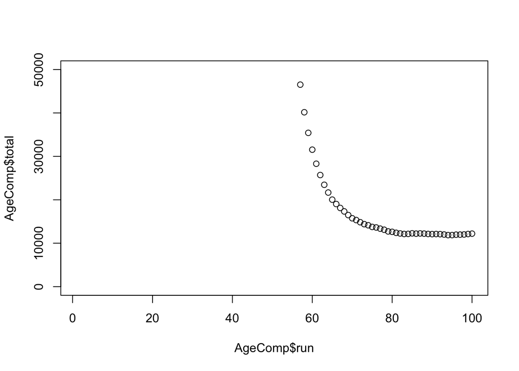

```r
AgeComp <- out[[1]]

AgeComp2 <- AgeComp[,c(1,3:9)]
names(AgeComp2) <- c("Year", "Age2", "Age3", "Age4", "Age5", "Age6", "Age7", "Age8")

AgeComp2 <- melt(AgeComp2, id.vars = "Year")
AgeComp2$Age <- as.factor(AgeComp2$variable)
AgeComp2$AgeNumeric <- as.numeric(gsub("Age", "", x=AgeComp2$variable))
AgeComp2 <- AgeComp2[AgeComp2$AgeNumeric>=3 & AgeComp2$AgeNumeric <=7,]


all <-  ggplot(data = AgeComp2, aes(x = Year, y = value, group = AgeNumeric, shape = Age,
                                    color = Age)) +
  geom_point(size = 0.8) + geom_line() + ylim(0,  5000) +
  stat_smooth(aes(y=value, x=Year), method = lm, formula = y ~ poly(x, 5), se = FALSE, size = 0.5)+
  theme(axis.title.x=element_blank(), axis.text.x=element_blank(), axis.ticks.x=element_blank(),
        axis.title.y=element_blank())#, axis.text.y=element_blank(), axis.ticks.y=element_blank())

age7 <- ggplot(data = filter(AgeComp2, AgeNumeric >= 7), aes(x = Year, y = value, group = AgeNumeric, shape = Age, color = Age)) +
  geom_point() + geom_line() + ylim(0, 3000) +
  stat_smooth(aes(y=value, x=Year), method = lm, formula = y ~ poly(x, 5), se = FALSE)+
  theme(axis.title.x=element_blank(), axis.text.x=element_blank(), axis.ticks.x=element_blank(),
        axis.title.y=element_blank())#, axis.text.y=element_blank(), axis.ticks.y=element_blank())

AgeComp$Comp <- "female"
otro <- ggplot(data = AgeComp, aes(x = run, y = sexComp, shape = Comp)) +
  geom_point() + geom_line() + ylim(0.4,0.6) + xlab("Time [Years]") +
  stat_smooth(aes(y=sexComp, x=run), method = lm, formula = y ~ poly(x, 5), se = FALSE)+
  theme(axis.title.x=element_blank(), axis.text.x=element_blank(), axis.ticks.x=element_blank(),
        axis.title.y=element_blank())#, axis.text.y=element_blank(), axis.ticks.y=element_blank())

plot(AgeComp$run, AgeComp$total, ylim=c(0,50000))
```

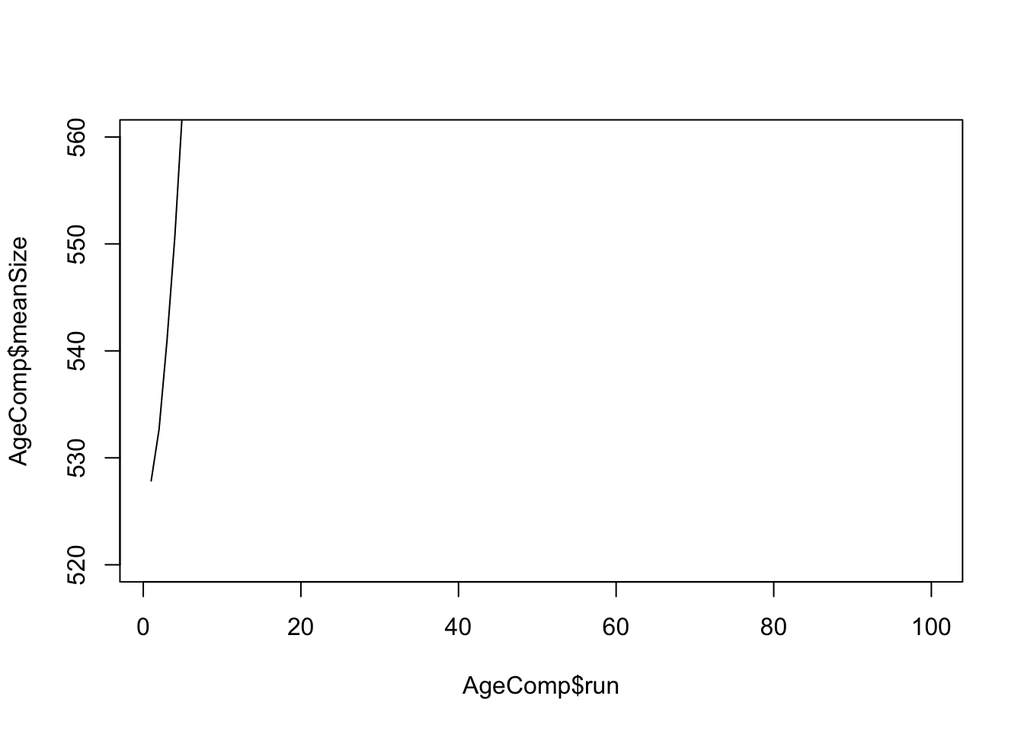

```r
plot(AgeComp$run, AgeComp$meanSize, type="l", ylim=c(520,560))
```

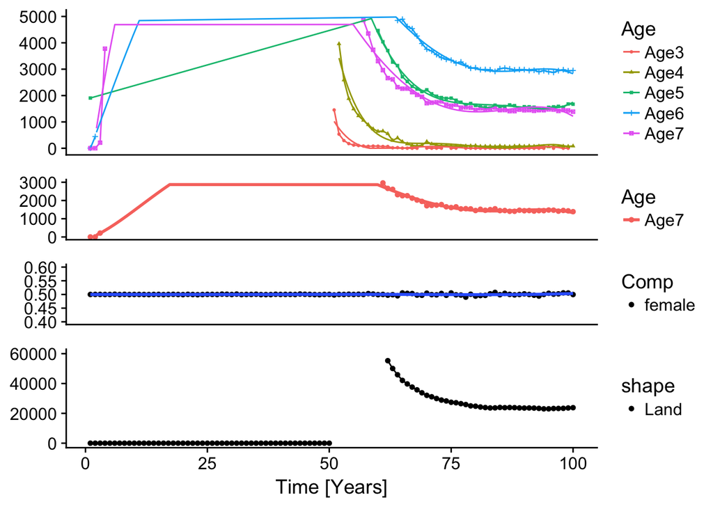

```r
landings <- ggplot(AgeComp, aes(x=run, y=landings, shape = "Land")) +
  geom_point() + geom_line() + ylim(0, 60000) +
  xlab("Time [Years]") +
  theme(axis.title.y=element_blank())

plot_grid(all, age7, otro, landings, ncol=1, nrow=4, align = "v", rel_heights = c(2, 1, 1,2))
```